# MATH-2620_HW-03

Liam Mason

2025-11-07

*This code is from a problem set for my MATH-2620 Statistical Learning & Data Science class. Problems from Chapter 5 work with resampling methods. Problems from Chapter 6 work with model selection methods. More information about each problem is explained below.*

# Libraries

```r
library(glmnet)
library(boot)
library(leaps)
library(pls)
```

# Chapter 5

## Problem 2

*In this problem, I calculate the theoretical probability that observation j of a data set occurs in a bootstrap sample and then test that theory in practice. Both theoretical calculation and empirical observation indicate that as n nears infinity, the probability that the jth observation is in the bootstrap sample is approximately 0.632. This makes sense given the limit definition of e^x, as 1-e^(-1) =~0.632.*

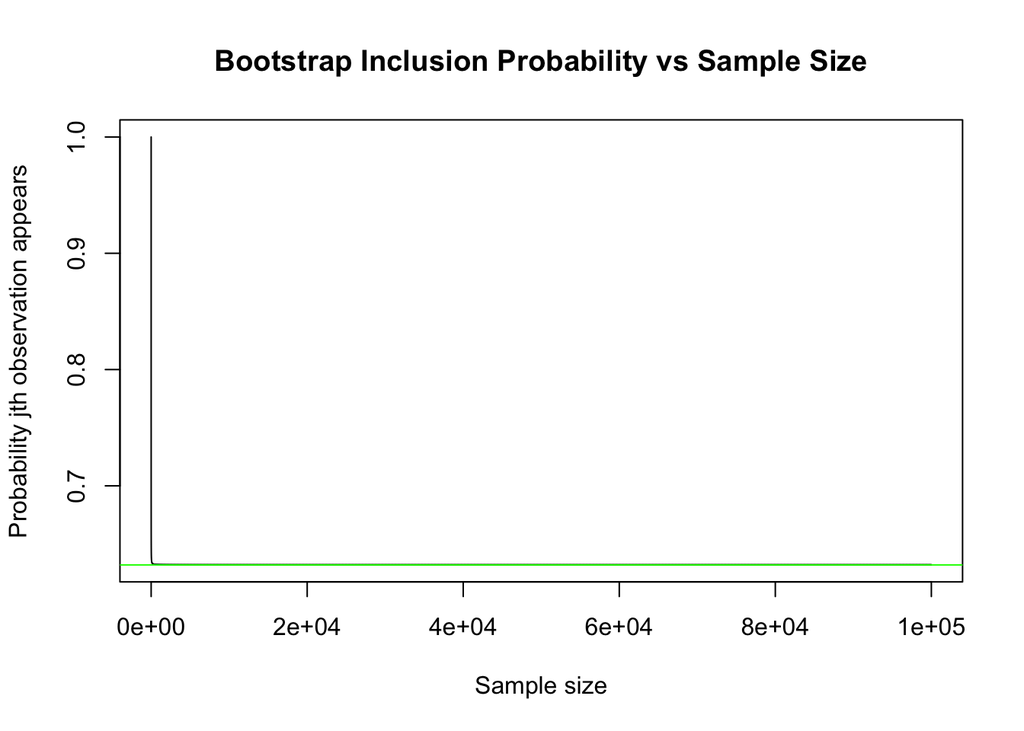

```r
### Part G ###
n = 1:100000
pr = 1 - (1 - 1/n)^n
plot(n, pr, type = "l",
     xlab = "Sample size",
     ylab = "Probability jth observation appears",
     main = "Bootstrap Inclusion Probability vs Sample Size")
abline (h = 0.632, col = 'green')
```

```r
### Part H ###
store = rep(NA, 10000)
for(i in 1:10000){
  store[i] <- sum(sample(1:100, rep=TRUE) == 4) > 0
}
mean(store)
```

```
## [1] 0.6317
```